# Understanding Preventable Crash Patterns in Washington, DC

Car crashes are not just random events. They often follow patterns based on location, time, road conditions, driver behavior, and other surrounding factors. For this project, I will be analyzing a dataset on car crashes in Washington, DC to better understand where and when crashes happen, and what factors may make them more likely to occur.

The dataset represents recorded crash incidents across DC and includes information that can help identify trends in crash frequency, location, timing, severity, and possible contributing conditions. The source of the dataset is DC’s public data portal, which makes it useful because it reflects real transportation and public safety data from the city.

By analyzing this data, I can look beyond individual incidents and focus on broader trends that may reveal risk areas, repeated conditions, or preventable factors connected to crashes in DC.

## Objective and Research Question

The main objective of this project is to identify preventable patterns in car crash occurrences across Washington, DC. Instead of only looking at the total number of crashes, this analysis will focus on the conditions and trends that may explain why crashes happen more often in certain places, times, or situations.

### Research Question

**What are the preventable patterns seen in car crash occurrences in Washington, DC?**

To answer this question, I will explore patterns such as:

- Whether crashes happen more often in certain areas of DC
- Whether crash frequency changes based on time of day, day of the week, or season
- Whether specific crash types or conditions appear repeatedly
- Whether certain factors are connected to more severe or frequent crashes

The goal is to use the data to better understand which crash patterns may be predictable and potentially preventable through safer driving, better road design, traffic enforcement, or public awareness.

### Importing Dataset and Required Libraries

```python
import pandas as pd
import matplotlib.pyplot as plt
import seaborn as sns
import plotly.express as px

df = pd.read_csv('Crashes_in_DC.csv')
```

```python
df.head()
```

|  | X | Y | CRIMEID | CCN | REPORTDATE | ROUTEID | MEASURE | OFFSET | STREETSEGID | ROADWAYSEGID | ... | MAR_ID | BLOCKKEY | SUBBLOCKKEY | CORRIDORID | NEARESTINTKEY | MAJORINJURIESOTHER | MINORINJURIESOTHER | UNKNOWNINJURIESOTHER | FATALOTHER | OBJECTID |
| --- | --- | --- | --- | --- | --- | --- | --- | --- | --- | --- | --- | --- | --- | --- | --- | --- | --- | --- | --- | --- | --- |
| 0 | -8.565544e+06 | 4.707520e+06 | 23637855 | 11048692 | 2011/04/11 06:19:00+00 | 12051802 | 1307.68 | 0.08 | 1715.0 | 2362.0 | ... | 301198 | d0525b56a652a6e0ee1cee2543c0c0c9 | 6aedc6da912081a340a20901f009060e | 11064672_1 | 0dc819495f66aa43f8c8df4311f0fae1 | NaN | NaN | NaN | NaN | 463060129 |
| 1 | -8.574969e+06 | 4.707980e+06 | 23638295 | 11048940 | 2011/04/11 20:00:00+00 | Route not found | 0.00 | 0.00 | -9.0 | 29942.0 | ... | 300400 | Unknown | Unknown | Unknown | Unknown | NaN | NaN | NaN | NaN | 463060130 |
| 2 | -8.573122e+06 | 4.708657e+06 | 23639908 | 11050581 | 2011/04/14 00:00:00+00 | Route not found | 0.00 | 0.00 | -9.0 | 26064.0 | ... | 238253 | Unknown | Unknown | Unknown | Unknown | NaN | NaN | NaN | NaN | 463060131 |
| 3 | -8.571574e+06 | 4.711824e+06 | 23640100 | 11049653 | 2011/04/12 04:00:00+00 | Route not found | 0.00 | 0.00 | -9.0 | 33008.0 | ... | 302303 | Unknown | Unknown | Unknown | Unknown | NaN | NaN | NaN | NaN | 463060132 |
| 4 | -8.568233e+06 | 4.711586e+06 | 23640391 | 11050068 | 2011/04/13 18:55:00+00 | 12081442 | 1766.26 | 0.06 | 3621.0 | 4091.0 | ... | 804198 | fe59a17365095d323c2bafd5c7c7a30f | fe59a17365095d323c2bafd5c7c7a30f | 12081442_1 | 29e62c0e766cd560bb048a8bf8e6d691 | NaN | NaN | NaN | NaN | 463060133 |

5 rows × 66 columns

```python
df.columns
```

```
Index(['X', 'Y', 'CRIMEID', 'CCN', 'REPORTDATE', 'ROUTEID', 'MEASURE',
       'OFFSET', 'STREETSEGID', 'ROADWAYSEGID', 'FROMDATE', 'TODATE',
       'ADDRESS', 'LATITUDE', 'LONGITUDE', 'XCOORD', 'YCOORD', 'WARD',
       'EVENTID', 'MAR_ADDRESS', 'MAR_SCORE', 'MAJORINJURIES_BICYCLIST',
       'MINORINJURIES_BICYCLIST', 'UNKNOWNINJURIES_BICYCLIST',
       'FATAL_BICYCLIST', 'MAJORINJURIES_DRIVER', 'MINORINJURIES_DRIVER',
       'UNKNOWNINJURIES_DRIVER', 'FATAL_DRIVER', 'MAJORINJURIES_PEDESTRIAN',
       'MINORINJURIES_PEDESTRIAN', 'UNKNOWNINJURIES_PEDESTRIAN',
       'FATAL_PEDESTRIAN', 'TOTAL_VEHICLES', 'TOTAL_BICYCLES',
       'TOTAL_PEDESTRIANS', 'PEDESTRIANSIMPAIRED', 'BICYCLISTSIMPAIRED',
       'DRIVERSIMPAIRED', 'TOTAL_TAXIS', 'TOTAL_GOVERNMENT',
       'SPEEDING_INVOLVED', 'NEARESTINTROUTEID', 'NEARESTINTSTREETNAME',
       'OFFINTERSECTION', 'INTAPPROACHDIRECTION', 'LOCATIONERROR',
       'LASTUPDATEDATE', 'MPDLATITUDE', 'MPDLONGITUDE', 'MPDGEOX', 'MPDGEOY',
       'FATALPASSENGER', 'MAJORINJURIESPASSENGER', 'MINORINJURIESPASSENGER',
       'UNKNOWNINJURIESPASSENGER', 'MAR_ID', 'BLOCKKEY', 'SUBBLOCKKEY',
       'CORRIDORID', 'NEARESTINTKEY', 'MAJORINJURIESOTHER',
       'MINORINJURIESOTHER', 'UNKNOWNINJURIESOTHER', 'FATALOTHER', 'OBJECTID'],
      dtype='object')
```

```python
df.info()
```

```
<class 'pandas.core.frame.DataFrame'>
RangeIndex: 346851 entries, 0 to 346850
Data columns (total 66 columns):
 #   Column                      Non-Null Count   Dtype
---  ------                      --------------   -----
 0   X                           346851 non-null  float64
 1   Y                           346851 non-null  float64
 2   CRIMEID                     346851 non-null  int64
 3   CCN                         346851 non-null  object
 4   REPORTDATE                  345474 non-null  object
 5   ROUTEID                     346851 non-null  object
 6   MEASURE                     346851 non-null  float64
 7   OFFSET                      346851 non-null  float64
 8   STREETSEGID                 215903 non-null  float64
 9   ROADWAYSEGID                215903 non-null  float64
```

[output cut: 58 more lines]

```python
df.shape
```

```
(346851, 66)
```

```python
df.describe()
```

|  | X | Y | CRIMEID | MEASURE | OFFSET | STREETSEGID | ROADWAYSEGID | TODATE | LATITUDE | LONGITUDE | ... | FATALPASSENGER | MAJORINJURIESPASSENGER | MINORINJURIESPASSENGER | UNKNOWNINJURIESPASSENGER | MAR_ID | MAJORINJURIESOTHER | MINORINJURIESOTHER | UNKNOWNINJURIESOTHER | FATALOTHER | OBJECTID |
| --- | --- | --- | --- | --- | --- | --- | --- | --- | --- | --- | --- | --- | --- | --- | --- | --- | --- | --- | --- | --- | --- |
| count | 3.468510e+05 | 3.468510e+05 | 3.468510e+05 | 346851.000000 | 346851.000000 | 215903.000000 | 215903.000000 | 0.0 | 346851.000000 | 346851.000000 | ... | 346851.000000 | 346851.000000 | 346851.000000 | 346851.000000 | 346851.000000 | 93294.000000 | 93294.000000 | 93294.0 | 93294.000000 | 3.468510e+05 |
| mean | -8.572374e+06 | 4.707915e+06 | 1.352824e+10 | 1679.475311 | 14.983575 | 5206.380069 | 14955.307231 | NaN | 38.903888 | -77.006057 | ... | 0.000291 | 0.017166 | 0.077814 | 0.006994 | 263675.235562 | 0.000986 | 0.013270 | 0.0 | 0.000064 | 4.646710e+08 |
| std | 4.049758e+03 | 4.473593e+03 | 2.325850e+10 | 1752.709214 | 13.760056 | 4690.124172 | 11443.282535 | NaN | 0.031243 | 0.371610 | ... | 0.018364 | 0.253355 | 0.371990 | 0.113027 | 201263.265041 | 0.031727 | 0.128044 | 0.0 | 0.008019 | 1.005695e+05 |
| min | -8.584768e+06 | 4.692099e+06 | 2.341134e+07 | 0.000000 | 0.000000 | -9.000000 | 0.000000 | NaN | 38.793241 | -77.118281 | ... | 0.000000 | 0.000000 | 0.000000 | 0.000000 | 1.000000 | 0.000000 | 0.000000 | 0.0 | 0.000000 | 4.630601e+08 |
| 25% | -8.575140e+06 | 4.705478e+06 | 2.662521e+07 | 388.620000 | 0.490000 | 0.000000 | 5562.000000 | NaN | 38.886901 | -77.031547 | ... | 0.000000 | 0.000000 | 0.000000 | 0.000000 | 150434.000000 | 0.000000 | 0.000000 | 0.0 | 0.000000 | 4.645843e+08 |
| 50% | -8.572610e+06 | 4.707947e+06 | 2.758779e+07 | 1150.300000 | 14.160000 | 4671.000000 | 12355.000000 | NaN | 38.904118 | -77.009199 | ... | 0.000000 | 0.000000 | 0.000000 | 0.000000 | 266455.000000 | 0.000000 | 0.000000 | 0.0 | 0.000000 | 4.646710e+08 |
| 75% | -8.569751e+06 | 4.710509e+06 | 2.956626e+10 | 2369.830000 | 24.540000 | 9246.000000 | 22668.000000 | NaN | 38.921987 | -76.983430 | ... | 0.000000 | 0.000000 | 0.000000 | 0.000000 | 300822.000000 | 0.000000 | 0.000000 | 0.0 | 0.000000 | 4.647578e+08 |
| max | -8.561530e+06 | 4.720920e+06 | 6.979984e+10 | 10660.870000 | 50.000000 | 15824.000000 | 40635.000000 | NaN | 38.994746 | 77.012701 | ... | 3.000000 | 51.000000 | 17.000000 | 15.000000 | 914195.000000 | 2.000000 | 5.000000 | 0.0 | 1.000000 | 4.648445e+08 |

8 rows × 49 columns

## DATA CLEANING STAGE

```python
# Creating a copy so the original dataframe stays unchanged
crashes = df.copy()

# Storing original shape for comparison later
original_rows, original_columns = crashes.shape
```

```python
#checking for missing values
missing_values = crashes.isnull().sum()
print(missing_values)
```

```
X                            0
Y                            0
CRIMEID                      0
CCN                          0
REPORTDATE                1377
                         ...
MAJORINJURIESOTHER      253557
MINORINJURIESOTHER      253557
UNKNOWNINJURIESOTHER    253557
FATALOTHER              253557
OBJECTID                     0
Length: 66, dtype: int64
```

```python
# Showing all missing values in a full table
missing_values_table = pd.DataFrame({
    "column_name": crashes.columns,
    "missing_count": crashes.isnull().sum().values,
    "missing_percent": (crashes.isnull().sum().values / len(crashes) * 100).round(2)
})

missing_values_table = missing_values_table.sort_values(by="missing_percent", ascending=False)
missing_only = missing_values_table[missing_values_table["missing_count"] > 0]

missing_only
```

|  | column_name | missing_count | missing_percent |
| --- | --- | --- | --- |
| 11 | TODATE | 346851 | 100.00 |
| 46 | LOCATIONERROR | 296730 | 85.55 |
| 64 | FATALOTHER | 253557 | 73.10 |
| 63 | UNKNOWNINJURIESOTHER | 253557 | 73.10 |
| 62 | MINORINJURIESOTHER | 253557 | 73.10 |
| 61 | MAJORINJURIESOTHER | 253557 | 73.10 |
| 47 | LASTUPDATEDATE | 224522 | 64.73 |
| 50 | MPDGEOX | 214485 | 61.84 |
| 51 | MPDGEOY | 214485 | 61.84 |
| 8 | STREETSEGID | 130948 | 37.75 |
| 9 | ROADWAYSEGID | 130948 | 37.75 |
| 18 | EVENTID | 93701 | 27.01 |
| 49 | MPDLONGITUDE | 65791 | 18.97 |
| 48 | MPDLATITUDE | 65791 | 18.97 |
| 19 | MAR_ADDRESS | 18584 | 5.36 |
| 59 | CORRIDORID | 8755 | 2.52 |
| 43 | NEARESTINTSTREETNAME | 6479 | 1.87 |
| 4 | REPORTDATE | 1377 | 0.40 |
| 12 | ADDRESS | 82 | 0.02 |
| 10 | FROMDATE | 75 | 0.02 |
| 42 | NEARESTINTROUTEID | 37 | 0.01 |
| 60 | NEARESTINTKEY | 37 | 0.01 |
| 57 | BLOCKKEY | 8 | 0.00 |
| 17 | WARD | 2 | 0.00 |

```python
#checking for duplicates
duplicate_rows = crashes.duplicated().sum()
print(f"Number of duplicate rows: {duplicate_rows}")
```

```
Number of duplicate rows: 0
```

### Handling Missing Values

The missing values in this dataset need to be handled based on how useful each column is for the research question. Columns that are completely empty, or duplicated by better columns will be removed from the working dataset.

Important count columns, such as injuries, fatalities, speeding, impairment, pedestrians, bicyclists, and vehicle counts, will be filled with 0 because missing values in these fields usually mean no recorded count for that category.

For important location and text columns, missing values will be filled with `"Unknown"` so those records can still be included in the analysis. Rows missing the main crash date will be removed because they cannot be used for time-based crash pattern analysis.

```python
crashes_clean = crashes.copy()

print("Original shape:", crashes_clean.shape)
```

```
Original shape: (346851, 66)
```

```python
# Dropping columns that are mostly missing or not useful for this project
columns_to_drop = [
    "TODATE",          # 100% missing
    "LOCATIONERROR",   # mostly missing and not needed
    "LASTUPDATEDATE",  # not needed for crash pattern analysis

    # Duplicate coordinate/geography columns with many missing values
    "MPDGEOX",
    "MPDGEOY",
    "MPDLATITUDE",
    "MPDLONGITUDE"
]

crashes_clean = crashes_clean.drop(columns=columns_to_drop, errors="ignore")

print("Shape after dropping unnecessary columns:", crashes_clean.shape)
```

```
Shape after dropping unnecessary columns: (346851, 59)
```

```python
# Convert FROMDATE to datetime
crashes_clean["FROMDATE"] = pd.to_datetime(crashes_clean["FROMDATE"], errors="coerce")

# Remove rows missing FROMDATE because this is the main crash date column
crashes_clean = crashes_clean.dropna(subset=["FROMDATE"])

print("Shape after removing rows with missing FROMDATE:", crashes_clean.shape)
print("Missing FROMDATE values left:", crashes_clean["FROMDATE"].isna().sum())
```

```
Shape after removing rows with missing FROMDATE: (346776, 59)
Missing FROMDATE values left: 0
```

```python
# These are count columns, so missing values can reasonably be filled with 0
count_columns = [
    "MAJORINJURIESOTHER",
    "MINORINJURIESOTHER",
    "UNKNOWNINJURIESOTHER",
    "FATALOTHER"
]

crashes_clean[count_columns] = crashes_clean[count_columns].fillna(0)

print("Missing values left in selected count columns:")
print(crashes_clean[count_columns].isna().sum())
```

```
Missing values left in selected count columns:
MAJORINJURIESOTHER      0
MINORINJURIESOTHER      0
UNKNOWNINJURIESOTHER    0
FATALOTHER              0
dtype: int64
```

```python
# Fill small missing values in useful text/location columns with "Unknown" to preserve these rows for analysis
text_location_columns = [
    "ADDRESS",
    "WARD",
    "NEARESTINTSTREETNAME",
    "NEARESTINTROUTEID",
    "NEARESTINTKEY",
    "MAR_ADDRESS",
    "CORRIDORID",
    "STREETSEGID",
    "ROADWAYSEGID",
    "EVENTID",
    "BLOCKKEY"
]

text_location_columns = [
    column for column in text_location_columns
    if column in crashes_clean.columns
]

text_missing_values = ["", " ", "NULL", "Null", "null", "UNKNOWN",  "unknown","N/A", "NA", "nan", "NaN", "<NA>"]

#I standardized placeholder values like `Null`, `NULL`, `unknown`, and blank strings across all object columns.
#This prevents the same missing category from appearing under different labels during frequency counts and visualizations.

for column in text_location_columns:
    crashes_clean[column] = (
        crashes_clean[column]
        .astype("string")
        .str.strip()
        .replace(text_missing_values, "Unknown")
        .fillna("Unknown")
    )

crashes_clean[text_location_columns] = crashes_clean[text_location_columns].fillna("Unknown")

print("Missing values left in selected text/location columns:")
print(crashes_clean[text_location_columns].isna().sum())
```

```
Missing values left in selected text/location columns:
ADDRESS                 0
WARD                    0
NEARESTINTSTREETNAME    0
NEARESTINTROUTEID       0
NEARESTINTKEY           0
MAR_ADDRESS             0
CORRIDORID              0
STREETSEGID             0
ROADWAYSEGID            0
EVENTID                 0
BLOCKKEY                0
dtype: int64
```

```python
# Check remaining missing values after basic cleaning
remaining_missing = pd.DataFrame({
    "column_name": crashes_clean.columns,
    "missing_count": crashes_clean.isnull().sum().values,
    "missing_percent": (crashes_clean.isnull().sum().values / len(crashes_clean) * 100).round(2)
})

remaining_missing = remaining_missing.sort_values(by="missing_percent", ascending=False)

remaining_missing[remaining_missing["missing_count"] > 0]
```

|  | column_name | missing_count | missing_percent |
| --- | --- | --- | --- |
| 4 | REPORTDATE | 1377 | 0.4 |

For REPORTDATE, since only 0.4% is missing, the safest move is to fill missing REPORTDATE with FROMDATE instead of deleting rows.

```python
# Fill missing REPORTDATE values using FROMDATE
crashes_clean["REPORTDATE"] = crashes_clean["REPORTDATE"].fillna(crashes_clean["FROMDATE"])

print("Missing REPORTDATE values left:", crashes_clean["REPORTDATE"].isna().sum())
```

```
Missing REPORTDATE values left: 0
```

```python
# Standardizing column names
crashes_clean.columns = (crashes_clean.columns
    .str.strip()
    .str.upper()
    .str.replace(" ", "_", regex=False)
)
```

```python
# Standardizing string entries by stripping whitespace and converting to string type
string_columns = crashes_clean.select_dtypes(include=["object", "string"]).columns

for column in string_columns:
    crashes_clean[column] = (
        crashes_clean[column]
        .astype("string")
        .str.strip()
    )
```

```python
# Confirming date columns are in datetime format
date_columns = ["FROMDATE", "REPORTDATE"]

for column in date_columns:
        crashes_clean[column] = pd.to_datetime(crashes_clean[column], errors="coerce")

crashes_clean[date_columns].dtypes
```

```
FROMDATE      datetime64[ns, UTC]
REPORTDATE    datetime64[ns, UTC]
dtype: object
```

```python
print("Final cleaned dataset shape:", crashes_clean.shape)

print("\nMissing values left:")
print(crashes_clean.isnull().sum()[crashes_clean.isnull().sum() > 0])

print("\nDuplicate rows left:")
print(crashes_clean.duplicated().sum())
```

```
Final cleaned dataset shape: (346776, 59)

Missing values left:
REPORTDATE    1377
dtype: int64

Duplicate rows left:
0
```

### Data Cleaning Summary

The dataset is now clean enough to move into feature engineering and exploratory data analysis.

## Feature Engineering

After cleaning the dataset, I created a small set of new features that will be used directly in the visual analysis. These features focus on time patterns, location patterns, crash severity, and preventable crash factors such as speeding, impairment, and vulnerable road user involvement.

```python
#Creating Time features for visuals
crashes_clean["CRASH_YEAR"] = crashes_clean["FROMDATE"].dt.year
crashes_clean["CRASH_MONTH"] = crashes_clean["FROMDATE"].dt.month
crashes_clean["CRASH_DAY_NAME"] = crashes_clean["FROMDATE"].dt.day_name()
```

```python
# Preventable crash pattern features
crashes_clean["SPEEDING_CRASH"] = crashes_clean["SPEEDING_INVOLVED"] > 0

crashes_clean["IMPAIRED_CRASH"] = ( (crashes_clean["DRIVERSIMPAIRED"] > 0) |(crashes_clean["PEDESTRIANSIMPAIRED"] > 0) | (crashes_clean["BICYCLISTSIMPAIRED"] > 0))

crashes_clean["VULNERABLE_ROAD_USER_CRASH"] = ((crashes_clean["TOTAL_PEDESTRIANS"] > 0) |(crashes_clean["TOTAL_BICYCLES"] > 0))
```

```python
#Confirming new features were created correctly
new_features = ["SPEEDING_CRASH", "IMPAIRED_CRASH", "VULNERABLE_ROAD_USER_CRASH"]
crashes_clean[new_features].head(20)
```

|  | SPEEDING_CRASH | IMPAIRED_CRASH | VULNERABLE_ROAD_USER_CRASH |
| --- | --- | --- | --- |
| 0 | False | False | False |
| 1 | False | False | False |
| 2 | False | False | False |
| 3 | False | False | False |
| 4 | False | False | False |
| 5 | False | False | False |
| 6 | False | False | False |
| 7 | False | False | False |
| 8 | False | False | False |
| 9 | False | False | False |
| 10 | True | False | False |
| 11 | False | False | False |
| 12 | False | False | False |
| 13 | False | False | False |
| 14 | False | False | True |
| 15 | False | False | False |
| 16 | False | False | False |
| 17 | False | False | False |
| 18 | False | False | False |
| 19 | False | False | True |

```python
# Export the cleaned and analysis-ready dataset
crashes_clean.to_csv("Noble_Adike_final_project.csv", index=False)

print("Cleaned dataset exported successfully.")
```

```
Cleaned dataset exported successfully.
```

## EXPLORATORY DATA ANALYSIS

Before creating visualizations, I will explore the cleaned dataset to understand the main crash patterns. This section looks at summary statistics, frequency counts, time trends, ward-level comparisons. These checks help decide which patterns are worth visualizing later.

```python
# Summary statistics for important numeric columns
numeric_columns = [
    "TOTAL_VEHICLES",
    "TOTAL_PEDESTRIANS",
    "TOTAL_BICYCLES",
    "SPEEDING_INVOLVED",
    "DRIVERSIMPAIRED",
    "PEDESTRIANSIMPAIRED",
    "BICYCLISTSIMPAIRED"
]

crashes_clean[numeric_columns].describe()
```

|  | TOTAL_VEHICLES | TOTAL_PEDESTRIANS | TOTAL_BICYCLES | SPEEDING_INVOLVED | DRIVERSIMPAIRED | PEDESTRIANSIMPAIRED | BICYCLISTSIMPAIRED |
| --- | --- | --- | --- | --- | --- | --- | --- |
| count | 346776.000000 | 346776.000000 | 346776.000000 | 346776.000000 | 346776.000000 | 346776.000000 | 346776.000000 |
| mean | 1.970255 | 0.052636 | 0.021025 | 0.021838 | 0.016728 | 0.001433 | 0.000196 |
| std | 0.575646 | 0.243613 | 0.147042 | 0.148174 | 0.128791 | 0.043768 | 0.014002 |
| min | 0.000000 | 0.000000 | -9.000000 | -9.000000 | 0.000000 | 0.000000 | 0.000000 |
| 25% | 2.000000 | 0.000000 | 0.000000 | 0.000000 | 0.000000 | 0.000000 | 0.000000 |
| 50% | 2.000000 | 0.000000 | 0.000000 | 0.000000 | 0.000000 | 0.000000 | 0.000000 |
| 75% | 2.000000 | 0.000000 | 0.000000 | 0.000000 | 0.000000 | 0.000000 | 0.000000 |
| max | 16.000000 | 12.000000 | 3.000000 | 2.000000 | 2.000000 | 4.000000 | 1.000000 |

```python
# Frequency counts for important categorical columns
print("Crash counts by ward:")
print(crashes_clean["WARD"].value_counts().head(10))

print("Crash counts by day of week:")
print(crashes_clean["CRASH_DAY_NAME"].value_counts())
```

```
Crash counts by ward:
WARD
Ward 2     71026
Ward 5     54005
Ward 6     50098
Ward 7     47738
Ward 8     42459
Ward 1     30379
Ward 4     29700
Ward 3     19938
Unknown     1433
Name: count, dtype: Int64
Crash counts by day of week:
CRASH_DAY_NAME
Friday       56421
Thursday     51984
Wednesday    51417
Tuesday      50354
Saturday     49541
Monday       45828
Sunday       41231
Name: count, dtype: int64
```

```python
# Crash counts by year
crashes_by_year = crashes_clean["CRASH_YEAR"].value_counts().sort_index()
crashes_by_year
```

```
CRASH_YEAR
1900        7
1915        1
1916        1
1920        1
1938        1
1972        1
1989        4
1990        5
1991        4
1992        3
1993        1
1994        2
1995        2
1996        3
```

[output cut: 31 more lines]

```python
# Crash counts by month
crashes_by_month = crashes_clean["CRASH_MONTH"].value_counts().sort_index()
crashes_by_month
```

```
CRASH_MONTH
1     26896
2     25680
3     29838
4     29365
5     30385
6     30357
7     29691
8     28627
9     29518
10    31430
11    27939
12    27050
Name: count, dtype: int64
```

```python
# Create pedestrian/bicycle crash feature
crashes_clean["PED_BIKE_CRASH"] = (
    (crashes_clean["TOTAL_PEDESTRIANS"] > 0) |
    (crashes_clean["TOTAL_BICYCLES"] > 0)
)

# Compare preventable crash patterns by ward
ward_summary = crashes_clean.groupby("WARD").agg(
    TOTAL_CRASHES=("OBJECTID", "count"),
    SPEEDING_CRASHES=("SPEEDING_CRASH", "sum"),
    IMPAIRED_CRASHES=("IMPAIRED_CRASH", "sum"),
    PED_BIKE_CRASHES=("PED_BIKE_CRASH", "sum")
).sort_values(by="TOTAL_CRASHES", ascending=False)

ward_summary
```

| WARD | TOTAL_CRASHES | SPEEDING_CRASHES | IMPAIRED_CRASHES | PED_BIKE_CRASHES |
| --- | --- | --- | --- | --- |
| Ward 2 | 71026 | 864 | 973 | 6148 |
| Ward 5 | 54005 | 1249 | 979 | 3137 |
| Ward 6 | 50098 | 988 | 734 | 3685 |
| Ward 7 | 47738 | 1698 | 1118 | 2093 |
| Ward 8 | 42459 | 1385 | 1057 | 2245 |
| Ward 1 | 30379 | 401 | 682 | 3252 |
| Ward 4 | 29700 | 669 | 555 | 1969 |
| Ward 3 | 19938 | 237 | 162 | 1384 |
| Unknown | 1433 | 33 | 1 | 81 |

### EDA Summary

In this section, I looked at crash counts by ward, month, and day of the week to identify basic location and time-based trends. I also compared preventable crash factors such as speeding, impairment, and pedestrian/bicycle involvement by ward.

Overall, this EDA helped narrow the project focus to the patterns that best connect to the research question: **What are the preventable patterns seen in car crash occurrences in DC?** The next step is to turn these findings into visualizations that make the crash patterns easier to compare and explain.

## VISUALIZATIONS

### Visualization 1: Crashes by Day of the Week

**Intent:** This visualization examines whether car crashes in Washington, DC happen more often on certain days of the week. This helps identify weekly patterns that may point to higher-risk travel days.

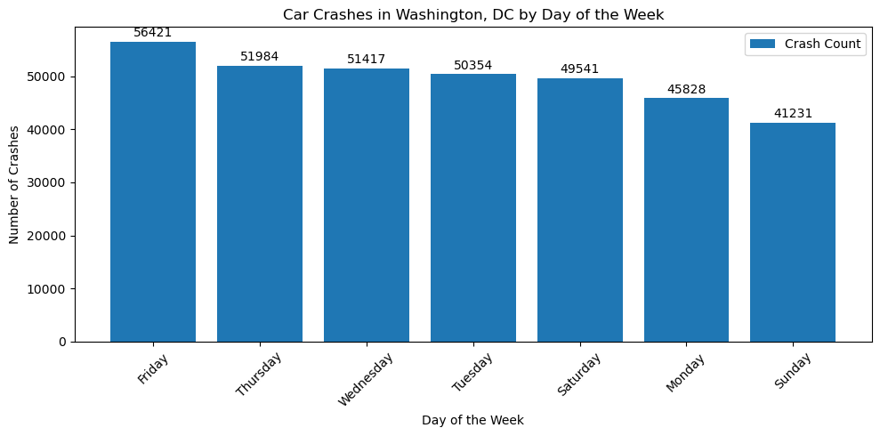

```python
crashes_by_day = crashes_clean["CRASH_DAY_NAME"].value_counts()

plt.figure(figsize=(10, 5))

crashes_bar = plt.bar(crashes_by_day.index, crashes_by_day.values, label="Crash Count")

plt.title("Car Crashes in Washington, DC by Day of the Week")
plt.xlabel("Day of the Week")
plt.ylabel("Number of Crashes")
plt.xticks(rotation=45)
plt.legend()

plt.bar_label(crashes_bar, fmt="%.0f", padding=2)

plt.tight_layout()
plt.savefig("visualizations/crashes_by_day.png")
plt.show()
```

### Visualization 2: Crashes by Year

**Intent:** This visualization shows how the number of car crashes in Washington, DC changed over the years.

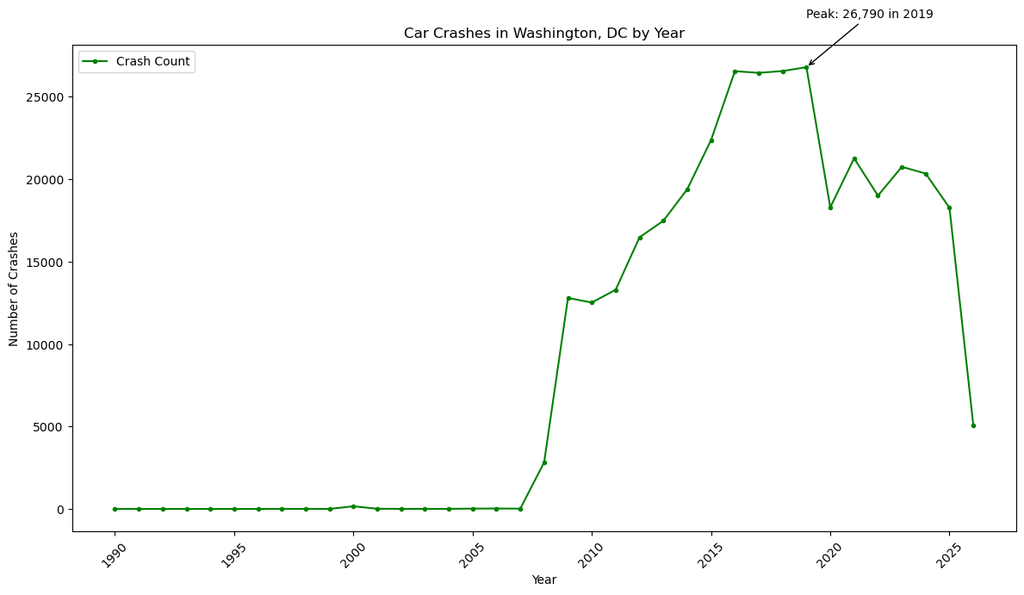

```python
crashes_by_year = crashes_clean.loc[crashes_clean["CRASH_YEAR"] >= 1990, "CRASH_YEAR"].value_counts().sort_index()

plt.figure(figsize=(12, 7))
plt.plot(crashes_by_year.index, crashes_by_year.values, marker=".", label="Crash Count", color="green")

plt.title("Car Crashes in Washington, DC by Year")
plt.xlabel("Year")
plt.ylabel("Number of Crashes")
plt.xticks(rotation=45)
plt.legend()

#annotating the peak year with an arrow and label
max_year = crashes_by_year.idxmax()
max_count = crashes_by_year.max()
plt.annotate(f"Peak: {max_count:,} in {max_year}", xy=(max_year, max_count), xytext=(max_year, max_count + 3000),
             arrowprops=dict(arrowstyle="->"))

plt.tight_layout()
plt.savefig("visualizations/crashes_by_year.png")
plt.show()
```

**Interpretation:** Crash totals increased over time and reached their highest point in 2019, with 26,790 crashes. After that peak, the number of crashes generally dropped, suggesting that crash frequency in DC changed noticeably after 2019 (covid most likely reason) instead of staying consistent across the years.

### Visualization 3: Preventable Crash Factor Totals

**Intent:** This visualization compares the main preventable crash factors in the dataset: speeding, impairment, and pedestrian/bicycle involvement.

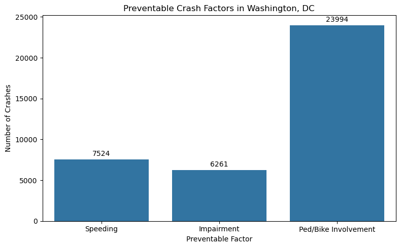

```python
preventable_counts = pd.DataFrame({
    "Preventable Factor": ["Speeding", "Impairment", "Ped/Bike Involvement"],
    "Crash Count": [crashes_clean["SPEEDING_CRASH"].sum(), crashes_clean["IMPAIRED_CRASH"].sum(), crashes_clean["PED_BIKE_CRASH"].sum()]
})

plt.figure(figsize=(8, 5))
ax = sns.barplot(data=preventable_counts, x="Preventable Factor", y="Crash Count")

plt.title("Preventable Crash Factors in Washington, DC")
plt.xlabel("Preventable Factor")
plt.ylabel("Number of Crashes")

for container in ax.containers:
    ax.bar_label(container, fmt="%.0f", padding=3)

plt.tight_layout()
plt.savefig("visualizations/preventable_factors.png")
plt.show()
```

**Interpretation:** Pedestrian/bike involvement has the highest count, with 23,994 crashes, making it the most common preventable factor shown in this chart. This suggests that vulnerable road users may require the most attention in DC crash prevention efforts.

### Visualization 4: Monthly Crash Trends by Ward

**Intent:** This FacetGrid shows how crash counts change by month across each DC ward. This helps compare location and time together instead of looking at only one variable at a time.

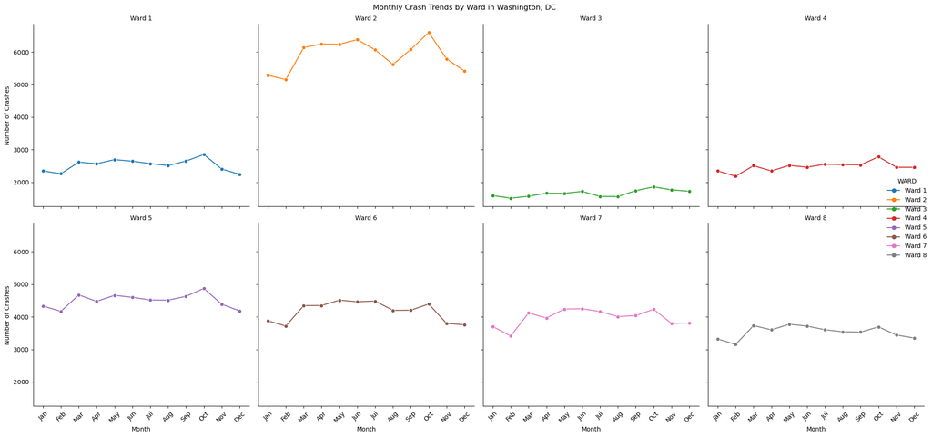

```python
ward_data = crashes_clean[crashes_clean["WARD"].str.contains("Ward")]
ward_month_counts = (ward_data.groupby(["WARD", "CRASH_MONTH"]).size().reset_index(name="CRASH_COUNT"))
ward_order = [f"Ward {i}" for i in range(1, 9)]

g = sns.relplot(data=ward_month_counts, x="CRASH_MONTH", y="CRASH_COUNT", col="WARD", col_order=ward_order, hue="WARD", kind="line", col_wrap= 4, marker="o")

g.set_axis_labels("Month", "Number of Crashes")
g.set_titles("{col_name}")
g.fig.suptitle("Monthly Crash Trends by Ward in Washington, DC")

for ax in g.axes.flat:
    ax.set_xticks(range(1, 13))
    ax.set_xticklabels(["Jan", "Feb", "Mar", "Apr", "May", "Jun","Jul", "Aug", "Sep", "Oct", "Nov", "Dec"], rotation=45)

plt.tight_layout()
g.savefig("visualizations/monthly_trends_by_ward.png")
plt.show()
```

**Interpretation:** This FacetGrid shows that monthly crash patterns differ by ward, but Ward 2 clearly stays the highest across every month. Several wards show slight increases around the spring and fall months, especially near October, while lower-count wards like Ward 3 remain more stable. This suggests that crash patterns in DC are shaped by both location and time, with some wards consistently needing more crash-prevention attention than others.

### Visualization 5: Distance From Intersection by Speeding Involvement

**Intent:** This box plot compares how far crashes occur from intersections based on whether speeding was involved. This helps explore whether speeding-related crashes follow a different location pattern than non-speeding crashes.

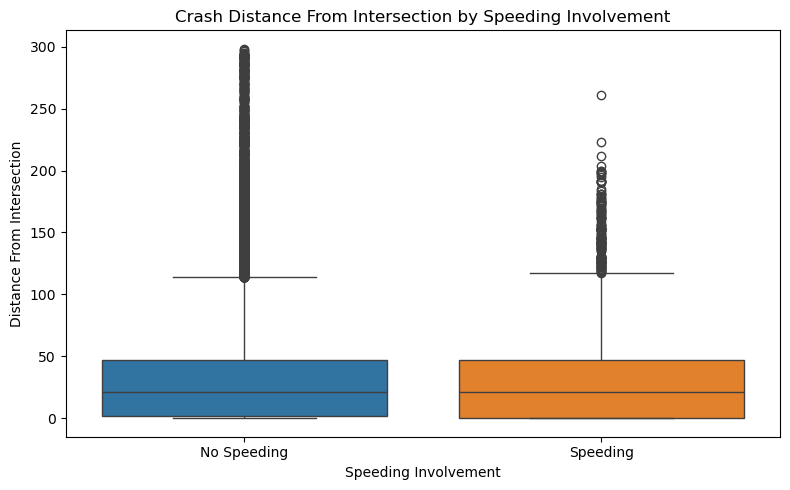

```python
speeding_distance_data = crashes_clean[crashes_clean["OFFINTERSECTION"].between(0, 300)].copy()

speeding_distance_data["SPEEDING_LABEL"] = speeding_distance_data["SPEEDING_CRASH"].map({True: "Speeding",False: "No Speeding"})

plt.figure(figsize=(8, 5))
ax = sns.boxplot(data=speeding_distance_data, x="SPEEDING_LABEL", y="OFFINTERSECTION", hue="SPEEDING_LABEL")

plt.title("Crash Distance From Intersection by Speeding Involvement")
plt.xlabel("Speeding Involvement")
plt.ylabel("Distance From Intersection")
plt.tight_layout()
plt.savefig("visualizations/distance_from_intersection.png")
plt.show()
```

**Interpretation:** This box plot shows that both speeding and non-speeding crashes usually happen close to intersections. The two distributions look fairly similar, which suggests that speeding crashes are not only happening far away from intersections. This matters because intersection areas may still need strong safety attention, even when looking specifically at speeding-related crashes.

### Visualization 6: Interactive grouped bar chart: Injuries and fatalities

**Intent:** This grouped bar chart compares crash injuries and fatalities across different road user types in Washington, DC. It shows whether bicyclists, drivers, pedestrians, passengers, or others are more affected by minor injuries, major injuries, or fatal crashes. This helps connect crash patterns to the actual human impact of traffic crashes.

```python
severity_cols = [
    "MINORINJURIES_BICYCLIST", "MAJORINJURIES_BICYCLIST", "FATAL_BICYCLIST",
    "MINORINJURIES_DRIVER", "MAJORINJURIES_DRIVER", "FATAL_DRIVER",
    "MINORINJURIES_PEDESTRIAN", "MAJORINJURIES_PEDESTRIAN", "FATAL_PEDESTRIAN",
    "MINORINJURIESPASSENGER", "MAJORINJURIESPASSENGER", "FATALPASSENGER",
    "MINORINJURIESOTHER", "MAJORINJURIESOTHER", "FATALOTHER"
]
severity_totals = crashes_clean[severity_cols].sum().reset_index(name="COUNT")
severity_totals[["SEVERITY", "ROAD_USER"]] = severity_totals["index"].str.extract(r"(MINORINJURIES|MAJORINJURIES|FATAL)_?(BICYCLIST|DRIVER|PEDESTRIAN|PASSENGER|OTHER)")

fig = px.bar(severity_totals, x="ROAD_USER", y="COUNT", color="SEVERITY", barmode="group", title="Crash Injuries and Fatalities by Road User Type in Washington, DC")
fig.show()
```

[output not shown]

**Interpretation:** Drivers suffer the most from crashes in this dataset, with the highest counts for both minor and major injuries. This matches the general assumption that drivers would appear most often because they are directly involved in most recorded crashes. Even though fatalities are much lower overall, the injury pattern still shows that drivers carry the largest share of crash impact in DC.

### Visualization 7: Interactive Map of Crash Locations

**Intent:** This interactive map shows where crashes are physically located across Washington, DC. By using latitude and longitude, the map helps identify crash clusters that may not be obvious from ward-level summaries alone.

```python
map_sample = crashes_clean.dropna(subset=["LATITUDE", "LONGITUDE"]).sample(5000, random_state=42)

fig = px.scatter_map(map_sample,lat="LATITUDE", lon="LONGITUDE", hover_data=["WARD", "FROMDATE", "SPEEDING_CRASH", "IMPAIRED_CRASH", "PED_BIKE_CRASH"],zoom=12, height=600, title="Interactive Map of Crash Locations in Washington, DC")

fig.update_layout(
    mapbox_style="open-street-map",
    margin={"r": 0, "t": 50, "l": 0, "b": 0}
)

fig.write_html("visualizations/crash_locations_map.html")
fig.show()
```

[output not shown]

### Visualization 8: Danger Zone Heatmap by Day and Hour (Surprise)

**Intent:** This heatmap identifies the specific day-and-hour combinations when crashes happen most often in Washington, DC. Instead of only looking at broad trends by month or year, this visualization shows smaller weekly crash patterns that may reveal rush-hour or late-night risk periods.

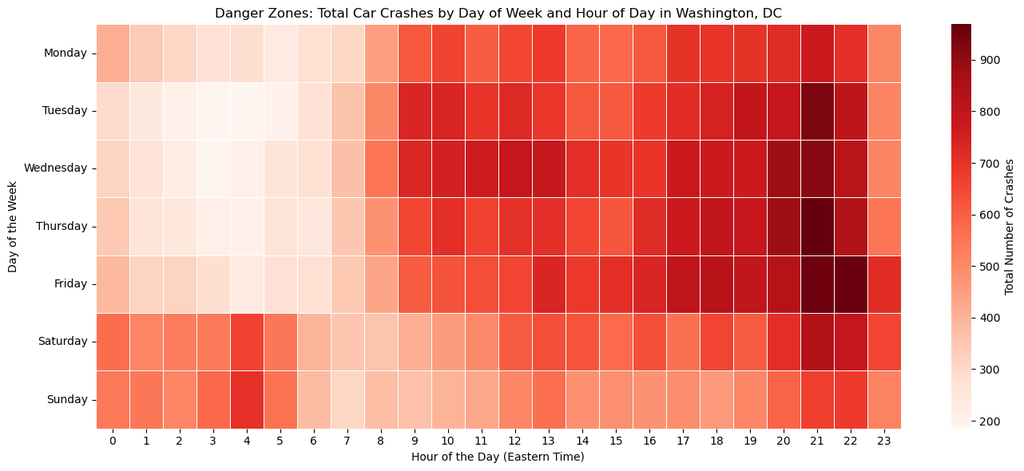

```python
# Convert crash time to Eastern Time
crashes_clean["FROMDATE_ET"] = pd.to_datetime(crashes_clean["FROMDATE"], errors="coerce", utc=True).dt.tz_convert("America/New_York")

# Keeping only rows that are not default midnight timestamps in Eastern Time
df_heatmap = crashes_clean[~((crashes_clean["FROMDATE_ET"].dt.hour == 0) & (crashes_clean["FROMDATE_ET"].dt.minute == 0) & (crashes_clean["FROMDATE_ET"].dt.second == 0))].copy()

# Create Eastern Time day and hour columns
df_heatmap["CRASH_HOUR"] = df_heatmap["FROMDATE_ET"].dt.hour
df_heatmap["CRASH_DAY_NAME"] = df_heatmap["FROMDATE_ET"].dt.day_name()

day_order = ["Monday", "Tuesday", "Wednesday", "Thursday", "Friday", "Saturday", "Sunday"]
heatmap_counts = pd.crosstab(df_heatmap["CRASH_DAY_NAME"], df_heatmap["CRASH_HOUR"]).reindex(day_order)

plt.figure(figsize=(14, 6))
sns.heatmap(heatmap_counts, cmap="Reds", linewidths=0.5, cbar_kws={"label": "Total Number of Crashes"})

plt.title("Danger Zones: Total Car Crashes by Day of Week and Hour of Day in Washington, DC")
plt.xlabel("Hour of the Day (Eastern Time)")
plt.ylabel("Day of the Week")
plt.tight_layout()
plt.savefig("visualizations/danger_zones_heatmap.png")
plt.show()
```

## ADDITIONAL ANALYSIS

### Additional Analysis 1: Crash Reporting Delay

**Motivation:** This analysis looks at how long it takes for crashes to be reported after they occur. This goes beyond the main crash-pattern question by examining the quality and timing of the reporting process itself.

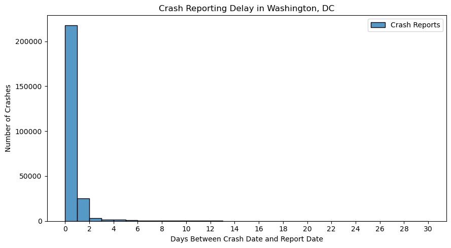

```python
crashes_clean["REPORT_DELAY_DAYS"] = (crashes_clean["REPORTDATE"] - crashes_clean["FROMDATE"]).dt.days

report_delay_data = crashes_clean[(crashes_clean["REPORT_DELAY_DAYS"] >= 0) &(crashes_clean["REPORT_DELAY_DAYS"] <= 30)]

plt.figure(figsize=(9, 5))

sns.histplot(data=report_delay_data, x="REPORT_DELAY_DAYS", bins=30, label="Crash Reports")
plt.xticks(range(0, 31, 2))
plt.title("Crash Reporting Delay in Washington, DC")
plt.xlabel("Days Between Crash Date and Report Date")
plt.ylabel("Number of Crashes")
plt.legend()


plt.tight_layout()
plt.show()
```

### Additional Analysis 2: Vehicles Involved per Crash

**Motivation:** This analysis explores crash complexity by looking at how many vehicles are involved in each crash. This helps show whether crashes are usually single-vehicle, two-vehicle, or larger multi-vehicle events.

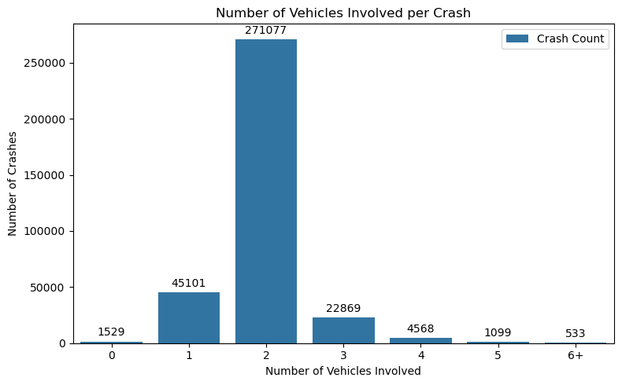

```python
vehicle_counts = crashes_clean["TOTAL_VEHICLES"].copy()

# Grouping counts of 6 or more vehicles into a single "6+" category for clearer visualization
vehicle_counts_grouped = vehicle_counts.apply(
    lambda x: "6+" if x >= 6 else str(int(x))
)

vehicle_order = ["0", "1", "2", "3", "4", "5", "6+"]

vehicle_summary = vehicle_counts_grouped.value_counts().reindex(vehicle_order).fillna(0)

plt.figure(figsize=(8, 5))

ax = sns.barplot(x=vehicle_summary.index, y=vehicle_summary.values, label="Crash Count")

plt.title("Number of Vehicles Involved per Crash")
plt.xlabel("Number of Vehicles Involved")
plt.ylabel("Number of Crashes")
plt.legend()

for container in ax.containers:
    ax.bar_label(container, fmt="%.0f", padding=3)

plt.tight_layout()
plt.show()
```

## INSIGHTS AND CONCLUSION

### Research Question Answered Or Not?

My research question was answered because the analysis showed that car crashes in Washington, DC do follow preventable patterns instead of happening randomly. The clearest patterns appeared in crash timing, ward location, vulnerable road user involvement, and repeated high-risk periods. This means crash prevention efforts can be more targeted instead of treating every crash as an isolated event.

### Most Significant Patterns and Trends

One major trend was that crashes were highest on Fridays, with 56,421 crashes, while Sundays had the lowest total. Crashes also increased over time and reached their highest yearly point in 2019 with 26,790 crashes before dropping afterward. Ward 2 consistently had the highest monthly crash counts, showing that some areas of DC experience more crash activity than others.

### Limitations

One limitation is that this dataset only includes recorded crashes, so it may not fully represent crashes that were missing, delayed, or incorrectly reported. Some time values had to be cleaned because default or unknown crash times could affect time-based analysis. Also, the dataset does not fully explain why crashes happened because it does not include every possible factor, such as traffic volume, weather, road design, or driver behavior details.

### Future Investigation

In the future, this analysis could be improved by adding traffic volume, weather, road type, and road design data to better explain why certain crash patterns happen. A deeper hotspot analysis could also help identify specific streets or intersections that need safety improvements. Another useful next step would be building a predictive model to estimate when and where crashes are most likely to occur.